# گزارش پروژه‌ی درس تحلیل‌داده‌ها

آنالیز بازی‌های شطرنج

مهبد مجید ۹۵۱۰۹۳۷۲

2018-07-22 02:57:35

اهداف و قسمت‌های پروژه

قسمت‌های این پروژه را می‌توان به‌طور کلی به سه قسمت تقسیم‌کرد.

قسمت اول گه مربوط به کرال‌کردن داده از سایت فیده و تمیزکردن آن‌هاست. در این بخش یک کرالر برای گرفتن داده‌ها از سایت فیده نوشته‌شد و سپس هم یک تابع برای پاک‌سازی آن‌ها.

قسمت دوم که مربوط به پاک‌سازی داده‌های فرمت PGN است. در این قسمت از داده‌ی Aepli موجود در وبسایت

https://chessdatabaseandmore.blogspot.com/

استفاده‌کردیم. در این قسمت تابعی برای پاک‌سازی و تبدیل این نوع داده‌ها به داده‌ی با فرمت CSV نوشته‌شده است. ولی از آنجایی که اجرای این تابع زمان‌بر است تابعی هم برای این که داده‌ی اصلی را بخش بخش کند و تعدادی از بخش‌های آن را نمونه بگیرد نوشته‌شده‌است تا بتوان با بخش‌های کوچتری از داده‌ی اصلی کار کرد.

قسمت سوم که مربوط به استفاده از داده‌های به‌دست آمده و یافتن نتایج جالب است.

> کارهای انجام‌شده در این قسمت عمدتن مربوط به جمع‌آوری داده از سایت FIDE و بعد هم تمیز کردن آن‌هاست.

جمع‌آوری داده‌های سایت FIDE

سایت FIDE در آدرس https://ratings.fide.com/download.phtml حاوی ریتینگ‌های فیده از سال ۲۰۰۰ و به بعد است. مشکلی که این داده‌ها دارند این است که تنها از جایی به بعد شامل داده‌های با فرمت XML هستند و پیش از آن تنها شامل داده‌هایی به فرمت txt هستند. و اگر که یکی از این داده‌ها را باز کنیم مشاهده می‌کنیم که این داده‌ها به‌شدت کثیف هستند. حال ما برای دست‌یافتن به داده‌های قابل کار کردن چند مرحله کار داریم. اول آن که داده‌ها را با استفاده از نوشتن یک crawler از سایت FIDE دانلود کنیم. سپس اینکه این داده‌ها را از حالت فشرده‌سازی خارج کنیم. و پس از آن هم داده‌ها را به فرمتی قابل استفاده در بیاوریم.س

نوشتن crawler

برای نوشتن crawler باید به چند نکته توجه می‌شد.

اول از همه اینکه داده‌ها برای از حدودای سال ۲۰۱۲ به قبل تنها شامل ریتینگ استندارد است و اصلا فرمت آدرس آن هم با پس از آن متفاوت است. برای دانلود کردن از سایت fide از پکیج `downloader` استفاده کردیم و همچنین برای از فشرده‌سازی خارج کردن آن ها هم از دستور unzip استفاده‌کردیم.

همچنین برای بازی‌های rapid و blitz هم به‌طور جداگانه crawlerی نوشتیم که از آن‌جایی که تنها با داده‌های بعد ۲۰۱۲ سر و کار دارند ساده‌تر اند.

مرحله‌ی اول پاک‌سازی داده‌ها

اگر که داده‌های دانلودشده را باز کنید مشاهده می‌کنید که این داده‌ها به شدت کثیف هستند و نیاز به پاک‌سازی دارند. برای تبدیل این داده‌ها که به فرمت تکست هستند به فرمت csv از یک ایده استفاده می‌کنیم. آن هم این است که در خط اول که مربوط به نام ستون‌هاست به دنبال جاهایی می‌گردیم که اسپیس پشت یک کلمه است. که البته این امر هم مشکلاتی را به همراه دارد زیرا در این داده اسم برخی از ستون‌ها مثل `ID NUMBER` هم به صورت `ID_NUMBER` آمده و هم به صورت `ID NUMBER` که مورد دوم برای ایده‌ی گفته‌شده مشکل‌زا است. پس در این مرحله ابتدا نام برخی از ستون‌های برخی ماه‌ها را اصلاح می‌کنیم سپس به دنبال جاهایی که در آن‌ها اسپیس است و بعدش یک کلمه است می‌گردیم و سپس هم این جایگاه‌ها را با “” جایگزین می‌کنیم تا بتوانیم یک فایل

`tab_separated` داشته باشیم. (به این دلیل از خود کاما استفاده نمی‌کنیم که قسمت نام خود شامل کاما است.)

فایل های مربوط به این قسمت با فرمت `fide_parser` هستند.

مرحله‌ی دوم پاک‌سازی داده‌ها

حال اگر که یکی از فایل‌های csv ایجاد شده را باز کنیم و بخوانیم مشاهده‌ می‌کنیم که همه چیز باز هم به شدت کثیف است. تمامی ستون‌ها و نام ستون‌ها تعداد ثابتی کاراکتر دارند و حاوی تعداد زیادی `white-space` هستند. همچنین نام ستون‌های داده‌های قدیمی‌تر با نام ستون‌های داده‌های جدیدتر متفاوت است. در این مرحله این مشکلات را رفع می‌کنیم و نتایج را ذخیره‌سازی می‌کنیم.

فایل مربوط به این قسمت `good_csv` است.

ملحق کردن داده‌ها به یکدیگر

برای اینکه بتوانیم با این داده‌ها کار کنیم نیاز است که آن‌ها را کنار هم قرار دهیم. ولی نکته‌ای که هست این است که به ما در هر فایل به ازای هر ماه ریتینگ و مشخصات فرد را داریم. برای اینکه به هدفمان دست پیدا کنیم، داده‌هایمان را tidy می‌کنیم، به این صورت که اطلاعات مهم شخص را به همراه ریتینگش و زمان ثبت آن داده در یک سطر قرار می‌دهیم و سپس همه‌ی این سطرها را با یکدیگر `rbind` می‌کنیم. نتایج را هم به صورت جداگانه در ۲ فایل `meta` که مربوط به اطلاعات بازیکنان در گذر زمان است و `rating` که مربوط به ریتینگشان در گذر زمان است قرار می‌دهیم.

فایل مربوط به این قسمت `fide_standard_joiner` است.

بررسی‌کردن داده‌ی ساخته‌شده

تابع `draw_time_series`

یکی از اولین نکاتی که هر شطرنج‌باز (یا شطرنج‌دوست) دوست‌دارد بداند و برایش جالب است مقایسه‌ی خودش یا سایر بازیکنان با هم در طی زمان است. ما برای این کار یک تابع می‌نویسیم که با گرفتن آی‌دی بازیکنان و همچنین زمان شروع و پایان مورد نظر می‌تواند نمودار مقایسه‌ی این بازیکنان را به ما بدهد. در ادامه این بررسی را برای دو شطرنج‌باز بزرگ حال حاضر جهان یعنی آناند و کارلسن، و همچنین برای ۱۵ نفر برتر فعلی ایران انجام می‌دهیم.

مقایسه‌ی کشورهای جهان روی نقشه

اگر بخواهیم برای نقشه‌کشیدن از پکیج های‌چارتر استفاده کنیم باید بتوانیم کد کشورها را به فرمت مورد نیاز آن دربیاوریم. برای این‌کار باید از پکیج `countrycode` استفاده‌کنیم که از آنجایی که کد های استفاده‌شده توسط FIDE در هیچ کدام از استانداردهای کدگذاری نام کشورها موجود نیست باید آن‌ها را ابتدا به نام کامل کشورها تبدیل کنیم. که این کار با استفاده از داده‌ی موجود در سایت http://www.chessgames.com/alpha3.html و همچنین با استفاده از کد موجود در country_codes انجام می‌شود. پس روند کار به این صورت است: فرمت FIDE به فرمت کامل و از فرمت کامل به `iso2c` در نهایت هم برای مشاهده‌ی نتیجه نقشه‌ی تعداد بازیکنان فیده را برای تمامی کشورها می‌کشیم.

مقایسه‌ی آناند و کارلسن در طی زمان

```r
library(highcharter)
library(readr)
library(tidyr)
library(dplyr)
meta_data_df <- read_delim(file = "../integrated/meta",delim = "\t")
df_rating <- read_delim(file = "../integrated/rating",delim = "\t")
country_codes_df <- read_csv("../country_codes/country_codes.csv")


draw_time_series <- function(IDs, shared,start = as.Date("1900-05-01"), end = as.Date("2030-05-01")){
  df_rating %>%select(-K) %>% filter(ID %in% IDs, R_TIME <= end, R_TIME >= start) -> rating_over_time
  meta_data_df %>% filter(ID %in% IDs) %>% select(ID, NAME) %>% unique -> id_names
  left_join(rating_over_time, id_names) -> result

  return(result %>% arrange(R_TIME) %>%
    hchart("line", hcaes(x = R_TIME, y = RATING, group = NAME)) %>%
    hc_xAxis(title = list(text = "Time")) %>%
    hc_yAxis(title = list(text = "FIDE Rating"))  %>%
    hc_tooltip(crosshairs = T, shared = shared, sort = T) %>%
    hc_add_theme(hc_theme_sandsignika()))
}
draw_time_series(c(5000017, 1503014), T)
```

[interactive chart not shown]

شطرنج‌بازترین ملل

```r
meta_data_df %>% filter(R_TIME == as.Date("2018-05-01")) -> current_players

library(countrycode)
current_players %>%
  group_by(FED) %>%
  summarize(value = n()) %>%
  filter(nchar(FED) == 3) %>%
  rename(Abrv = FED) %>%
  full_join(country_codes_df) %>%
  mutate(Abrv = countrycode(Full, "country.name", "iso2c" )) %>%
  na.omit() %>%
  rename(`hc-key` = Abrv)-> by_country

hcmap("custom/world-robinson",
      data = by_country,
      value = "value",
      joinBy = c("hc-a2", "hc-key"),
      name = "No. of FIDE chess players",
      tooltip = list(valueDecimals = 0, valuePrefix = "", valueSuffix = " players"))
```

[interactive chart not shown]

سیر حرکت برترین ایرانی‌ها

```r
iranians <- current_players %>% filter(FED == "IRI") %>% select(ID) %>% unique()
top_iranians <- df_rating %>% filter(R_TIME == as.Date("2018-05-01"),
                                     ID %in% iranians$ID) %>% top_n(n = 15, wt = RATING) %>% .$ID %>% unique()

draw_time_series(top_iranians, T, start = as.Date("2010-01-01"))
```

[interactive chart not shown]

> کار های مربوط به این قسمت مربوط به پاک‌سازی داده‌های با فرمت PGN است.

پاک‌سازی داده‌های فرمت PGN و تبدیل آن‌ها به CSV

فرمت PGN به این صورت است که شامل تعدادی تگ پیش از حرکات هر بازی‌است که این تگ‌ها در واقع توضیحاتی درباره‌ی آن بازی هستند من‌جمله‌ی نام بازیکن‌ها، مسابقه، دور، نتیجه، تیم بازیکن‌ها و … . ولی نکته‌ای که هست این است که تمام بازی‌ها تمام این تگ‌ها را ندارند و ترتیب تگ‌ها ممکن است بسیار متفاوت باشد. برای نمونه می‌توانید داده‌ی زیر را بببینید که مربوط به خطوط یک بازی‌است.

```
   [2] "[Event \"Karposh Open 2012\"]"
   [3] "[Site \"Skopje MKD\"]"
   [4] "[Date \"2012.04.10\"]"
   [5] "[Round \"5.37\"]"
   [6] "[White \"Koksal, E. (wh)\"]"
   [7] "[Black \"Simjanovski, S. (bl)\"]"
   [8] "[Result \"1-0\"]"
   [9] "[WhiteElo \"2154\"]"
  [10] "[BlackElo \"2288\"]"
  [11] "[ECO \"A40\"]"
  [12] "1. d4 g6 2. c4 Bg7 3. e4 Nc6 4. Nf3 e5 5. dxe5 Nxe5 6. Nxe5 Bxe5 7. f4 Bg7"
  [13] "8. Be2 Qe7 9. Qd3 Qb4+ 10. Nc3 Bxc3+ 11. bxc3 Qe7 12. O-O d6 13. Bf3 f6 "
  [14] "14. Ba3 Nh6 15. e5 Bf5 16. Qd5 c6 17. Qa5 Nf7 18. Rfe1 fxe5 19. fxe5 O-O "
  [15] "20. exd6 Qh4 21. d7 Bxd7 22. Bxf8 Rxf8 23. Qc7 Bc8 24. Re4 Qf6 25. Rae1 "
  [16] "Qxc3 26. Qf4 Bf5 27. R4e3 Qb4 28. Qd4 a5 29. a3 Qd6 30. Qxd6 Nxd6 31. c5 "
  [17] "Nb5 32. Be2 Kg7 33. Bc4 h5 34. Re7+ Kf6 35. Bxb5 cxb5 36. Rxb7 Bd3 37. c6 "
  [18] "Rc8 38. c7 b4 39. axb4 axb4 40. Rc1 1-0"
```

تابع `pgn_cleaner`

وظیفه‌ی این تابع این است که بیاید و داده‌های با فرمت PGN را به داده‌های تمیز به صورت دیتافریم درآورد. در این تابع ما می‌آییم و ابتدا اندیس‌های شروع هر بازی را پیدا می‌کنیم. سپس برای هر بازی قسمت مربوط به آن‌را جدا می‌کنیم و در آن قسمت ابتدا مقادیر تگ‌ها و سپس حرکات را جدا می‌کنیم و در دیتافریممان می‌ریزیم.

نحوه‌ی خواندن از فایل

از آنجایی که فایل ما بسیار بزرگ است و دارای ۴ گیگابایت حجم و بیش از ۱۳۰ میلیون خط است، نمی توان تمام آن را پاک سازی کرد. بنابراین ما تصمیم می‌گیریم که تنها یک درصد آن را استفاده کنیم. برای این کار آن را به چانک‌های یک میلیون‌تایی تقسیم می‌کنیم و ۱۰ هزار خط اول آن را می‌خوانیم. در نهایت هر چانک را پس از تمیز شدن در فایل‌هایی ریختیم و سپس هم آن‌ها را با هم بایند کردیم تا یک فایل واحد به‌دست‌آید.

تابع `wrtie_files`

این تابع هر چانک را می‌خواند و تبدیل می‌کند و در فایل مربوط به آن می‌نویسد.

برخی یافته‌های جالب

شطرنج‌بازان در چه سنی به اوج دوران کاری خود می‌رسند؟

از آنجایی که پردازش این داده‌ها زمان‌بر است در هنگام اجرا یک‌بار آن‌ها را دخیره‌کرده‌ایم و اینجا تنها از نتیجه‌ی نهایی استفاده می‌کنیم.

```r
###########ATTENTION: uncomment to use original file
# meta_data_df <- read_delim(file = "integrated/meta",delim = "\t")
# df_rating <- read_delim(file = "integrated/rating",delim = "\t")
#
# library(dplyr)
#
# df_rating %>%
#   select(ID, R_TIME, RATING) %>%
#   inner_join(meta_data_df %>% select(ID, R_TIME),
#              by = c("ID", "R_TIME")) -> ID_RATING_TIME
#
# ID_RATING_TIME %>%
#   group_by(ID) %>%
#   top_n(n = 1, wt = RATING) %>%
#   ungroup() %>%
#   select(-RATING) %>%
#   inner_join(meta_data_df %>%
#                select(ID, BDAY) %>%
#                filter(BDAY !="0000", !is.na(BDAY)) %>%
#                unique()) -> BDAY_BEST_R_TIME
#
# write_csv(x = BDAY_BEST_R_TIME,path = "integrated/BDAY_BEST_R_TIME.csv")
#
# BDAY_BEST_R_TIME <- read_csv("integrated/BDAY_BEST_R_TIME.csv")
#
# BDAY_BEST_R_TIME %>%
#   mutate(age = as.numeric(format.Date(R_TIME, "%Y")) - as.numeric(BDAY)) %>%
#   .$age -> ages
# ages[(ages < 100) &(!is.na(ages))& ages > 0] -> best_ages
#
# table(best_ages) %>%
#   as.data.frame() %>%
#   mutate(best_ages = as.numeric(best_ages)) -> best_ages_table
#
# write_csv(best_ages_table, path = "integrated/BEST_AGES_TABLE.csv")

best_ages_table <- read_csv("../integrated/BEST_AGES_TABLE.csv")


best_ages_table %>%
  mutate(percent = round(Freq/sum(Freq),3)* 100) %>%
hchart(type = "area", hcaes(x = best_ages, y = Freq),
       marker = list(radius = 0),
       tooltip = list(pointFormat =
                        "Count: {point.Freq}<br/>
                         Percent: {point.percent}%<br/>")
       ) %>%
  hc_tooltip(valueDecimals = 0) %>%
  hc_xAxis(title = list(text = "Age"), crosshair = T) %>%
  hc_yAxis(title = list(text = "Count")) %>%
  hc_title(text = "Best Age in Chess Players' Career") %>%
  hc_tooltip(shared = T)  %>%
  hc_add_theme(hc_theme_sandsignika())
```

[interactive chart not shown]

در این نمودار مشاهده می ‌کنیم که اکثر شطرنج‌بازها در سن ۱۷ سالگی به بیشینه‌ی دوران فعالیت خود رسیده‌اند و درصد افرادی که در بعد از ۱۷ سالگی به اوج موفقیت خود رسیده‌اند از ۳۰ سالگی تا ۵۰ سالگی ثابت است و پس از آن هم با شیب زیادی کم می‌شود.

این پدیده را می‌توان از جهات زیادی مورد بررسی قرار داد من‌جمله اینکه در ۱۷ سالگی چه اتفاقی می‌افتد که اکثر شطرنج‌بازان دیگر پیشرفتی نمی‌کنند و نقطه‌ی اوج دوران فعالیتشان می‌شود ۱۷ سالگی. یکی از دلایل این امر می‌تواند این باشد که به‌دلایل مختلف از جمله دانشگاه شطرنج را رها می‌کنند.

تاثیر رنگ در ریتینگ‌های پایین‌تر بیشتر است یا ریتینگ‌های بالاتر

تاثیر رنگ در نتیجه بسیار جالب است. به این صورت که اگر سفید باشید در ریتینگ های بالاتر هم احتمال برد شما کمتر می شود و هم احتمال باختتان ولی نکته‌ای که هست این است که احتمال برد حریف شما با شیب بیشتری کاهش می‌یابد پس به طور کلی با افزایش ریتینگ شما شاهد احتمال بیشتر برد سفید در مقابل برد سیاه خواهید بودو

```r
library(tidyr)
library(dplyr)
library(ggplot2)
library(highcharter)

read_csv("../chunk_integrated/file.csv") -> bigfile
bigfile %>% mutate(WElo = as.numeric(WElo),
                        BElo = as.numeric(BElo)) %>%
  select(WElo, BElo, Result) %>%
  mutate(
    Ww = (Result == "1-0"),
    Wd = (Result == "1/2-1/2"),
    Wl = (Result == "0-1")
  ) %>%
  mutate(matchElo = (WElo + BElo) / 2) %>%
  mutate(matchElo = round(matchElo, -2)) %>%
  group_by(matchElo) %>%
  summarize(White_Winnigs = sum(Ww),
            White_Draws = sum(Wd),
            White_Loses = sum(Wl)) %>%
  drop_na() -> color_sig

color_sig %>% filter(White_Winnigs+White_Draws+White_Loses > 10)%>%
  gather(Partition, Count, White_Winnigs:White_Loses) %>%
  mutate(Partition = factor(Partition, levels = c("White_Winnings", "White_Draws", "White_Loses"))) %>%
  hchart(type = "area", hcaes(x = matchElo, y = Count, group = Partition),
         marker = list(radius = 0)) %>%
  hc_plotOptions(area = list(stacking = "percent")) %>%
  hc_tooltip(valueDecimals = 0) %>%
  hc_xAxis(title = list(text = "Match Rating"), crosshair = T) %>%
  hc_yAxis(title = list(text = "Percent (%)"), max = 100) %>%
  hc_title(text = "Match Rating effect on White's Result") %>%
  hc_tooltip(shared = T)  %>%
  hc_add_theme(hc_theme_sandsignika())
```

[interactive chart not shown]

```r
  color_sig %>% select(-matchElo)%>% chisq.test()
```

```
##
##  Pearson's Chi-squared test
##
## data:  .
## X-squared = 1459.4, df = 34, p-value < 2.2e-16
```

سیر تغییر ۱۰ شروع بازی برتر در چند سال اخیر(۱۰ حرکت ابتدای بازی)

یک نکته‌ی جالب که در مورد این نمودار وجود دارد این است که در دنیای شطرنج یک شروع بازی متداول می‌شود و همه در یک سال به سراغ آن می‌روند ولی سال بعد از آن دیگر کسی آن را بازی نمی‌کند. کمی شبیه چیزی که در دنیای مد مشاهده می‌کنیم. برای شفاف‌تر شدن موضوع می‌توانید نمودار زیر را مشاهده نمایید. در این نمودار می‌بینیم که یکی از شروع بازی‌های محبوب در یک سال بسیار محبوب می‌شود و سپس محبوبیت خود را در سال بعد از دست می‌دهد.

```r
library(stringr)
bigfile %>%
mutate(Moves =  str_trim(Moves)) %>%
  separate(col = Moves, into = paste0("M",as.character(0:20)),
           sep = "\\s*[:digit:]*\\.\\s*|\\s+") %>%
  select(-M0) %>%
  drop_na() %>%
  mutate(Open = paste(M1,M2,M3,M4,M5,M6,M7,M8,M9,M10)) %>%
  group_by(Open) %>%
  summarize(count = n()) %>%
  ungroup() %>%
  top_n(wt = count, n = 10) %>%
  arrange(desc(count))  -> pop_openings

bigfile %>%
  mutate(Moves =  str_trim(Moves)) %>%
  separate(col = Moves, into = paste0("M",as.character(0:20)),
           sep = "\\s*[:digit:]*\\.\\s*|\\s+") %>%
  select(-M0) %>%
  mutate(Open = paste(M1,M2,M3,M4,M5,M6,M7,M8,M9,M10)) %>%
  select(Open, Date) %>%
  drop_na() %>%
  mutate(Date = as.numeric(substr(start = 1, stop = 4,x = Date))) %>%
  filter(Open %in% pop_openings$Open) %>%
  group_by(Date, Open) %>%
  summarize(count = n()) %>%
  ungroup() %>%
  group_by(Open) %>%
  arrange(Date) -> pop_openings_dist
pop_openings_dist %>%
  hchart(type = "line", hcaes(x = Date, y = count, group = Open),
       marker = list(radius = 0)) %>%
  hc_tooltip(valueDecimals = 0) %>%
  hc_xAxis(title = list(text = "Year"), crosshair = T,min = 1990) %>%
  hc_yAxis(title = list(text = "Count")) %>%
  hc_tooltip(shared = T)  %>%
  hc_add_theme(hc_theme_sandsignika())
```

[interactive chart not shown]

```r
pop_openings_dist %>%
  filter(Date > 1990) %>%
  spread(key = Open, value = count) %>%
  select(-Date) %>%
  drop_na() %>%
  chisq.test()
```

```
##
##  Pearson's Chi-squared test
##
## data:  .
## X-squared = 2283.2, df = 45, p-value < 2.2e-16
```

در چند درصد موارد بازیکن با ریتینگ بالاتر برنده است و تاثیر اختلاف ریتینگ طرفین در توزیع نتیجه‌ی بازی

این نمودارها نکته‌ی خاصی ندارند و صرفن به ما شهودی می‌دهند از سطح معناداری اختلاف ریتینگ‌ها در شطرنج. تا بفهمیم هنگامی که گفته می‌شود فلان بازیکن از فلان بازیکن ۲۰۰ تا ریتینگش بیشتر است، تقریبی از احتمال نتیجه‌ی بازی میان این ۲ داشته‌یاشیم.

```r
bigfile %>% mutate(WElo = as.numeric(WElo),
                   BElo = as.numeric(BElo)) %>%
  select(WElo, BElo, Result) %>%
  mutate(
    Ww = (Result == "1-0"),
    Wd = (Result == "1/2-1/2"),
    Wl = (Result == "0-1")
  ) %>%
  mutate(
    WRating = if_else(Ww, true = WElo, false = BElo),
    LRating = if_else(Ww, true = BElo, false = WElo)
  ) %>%
  select(Draw = Wd, WRating, LRating) %>% drop_na() %>%
  mutate(StrongerStatus = if_else(Draw, "Draw", if_else(WRating > LRating, "Win", "Lose"))) %>%
  select(StrongerStatus) %>%
  group_by(StrongerStatus) %>%
  summarize(count = n()) %>%
  mutate(percent = round(count / sum(.$count), 3) * 100) %>%
  hchart(type = "pie",
         hcaes(
           x = StrongerStatus,
           y = count,
           name = as.factor(StrongerStatus)
         ),
         tooltip = list(pointFormat ="count: {point.count} <br/>
                           percent: {point.percent} % <br/>")
         ) %>%
  hc_title(text = "Stronger Person Results Ratio") %>%
  hc_add_theme(hc_theme_sandsignika())
```

[interactive chart not shown]

```r
##### Rating Difference Distribution
####################################
bigfile %>% mutate(WElo = as.numeric(WElo),
                   BElo = as.numeric(BElo)) %>%
  select(WElo, BElo, Result) %>%
  mutate(
    Ww = (Result == "1-0"),
    Wd = (Result == "1/2-1/2"),
    Wl = (Result == "0-1")
  ) %>%
  mutate(Wdif = WElo - BElo) %>%
  mutate(WResult = if_else(Ww, "W", if_else(Wd, "D", "L"))) %>%
  mutate(WResult = factor(WResult, levels = c("W", "D", "L"))) %>%
  select(WResult, Wdif) %>%
  mutate(Wdif = round(Wdif, -1)) %>%
  group_by(WResult, Wdif) %>%
  summarize(count = n()) %>%
  ungroup() %>%
  group_by(Wdif) %>%
  mutate(percent = round(count / sum(count),3) * 100) %>%
  ungroup() %>%
  drop_na() %>%
  hchart(type = "area", hcaes(x = Wdif, y = count, group = WResult),
         marker = list(radius = 0),
         tooltip = list(pointFormat ="<b>{point.WResult}</b> <br/> count: {point.count} <br/>
                           percent: {point.percent} % <br/>")) %>%
  hc_plotOptions(area = list(stacking = "percent")) %>%
  hc_tooltip(valueDecimals = 0) %>%
  hc_xAxis(title = list(text = "Match Rating"), crosshair = T, min = -600, max = 600) %>%
  hc_yAxis(title = list(text = "Percent (%)"), max = 100) %>%
  hc_tooltip(shared = T)  %>%
  hc_title(text = "Results Distribution by Rating Difference") %>%
  hc_add_theme(hc_theme_sandsignika())
```

[interactive chart not shown]

تاثیر اختلاف ریتینگ در ریتینگ‌های بالاتر بیشتر است یا ریتینگ‌های پایین‌تر

ریتینگ‌ها را در دسته‌های ۱۰۰ تایی قرار می‌دهیم و بازی‌هایی که میان افرادی از دسته‌ی یک ریتینگی و ۲۰۰ تا بیشتر از آن یا کمتر است را بررسی می‌کنیم و می‌بینیم در چند درصد موارد نتیجه چه طور بوده‌است و آیا اختلاف ریتینگ در سطوح مختلف تفاوتی دارد یا نه.

مشاهده می‌کنیم که سطج بازی‌کنان در معناداری اختلاف ریتینگ چندان تاثیرگذار نیست ولی تاثیرگذار هست(توزیع خیلی هم یونیفورم نیست. )

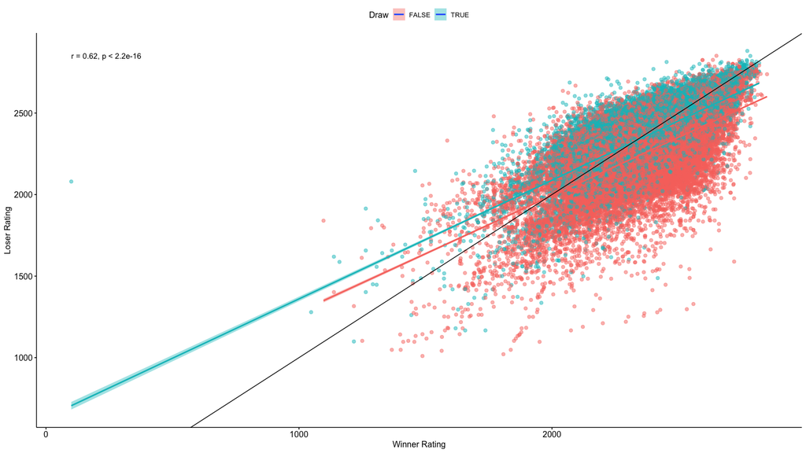

```r
library(tidyr)
library(dplyr)
library(ggplot2)

bigfile %>% mutate(WElo = as.numeric(WElo),
                        BElo = as.numeric(BElo)) %>%
  select(WElo, BElo, Result) %>%
  mutate(
    Ww = (Result == "1-0"),
    Wd = (Result == "1/2-1/2"),
    Wl = (Result == "0-1")
  ) %>%
  mutate(
    WRating = if_else(Ww, true = WElo, false = BElo),
    LRating = if_else(Ww, true = BElo, false = WElo)
  ) %>%
  select(Draw = Wd, WRating, LRating) %>% drop_na() %>%
  ggpubr::ggscatter(x = "WRating", y = "LRating",
                    add = "reg.line", conf.int = TRUE,
                    cor.coef = TRUE, cor.method = "spearman",
                    xlab = "Winner Rating", ylab = "Loser Rating",
                    color = "Draw", alpha = 0.5)+
  guides(color = F) +
  geom_abline(slope = 1, intercept = 0)
```

```r
bigfile %>%
  mutate(WElo = as.numeric(WElo), BElo = as.numeric(BElo)) %>%
  select(WElo, BElo, Result) %>%
  mutate(
    Ww = (Result == "1-0"),
    Wd = (Result == "1/2-1/2"),
    Wl = (Result == "0-1")
  ) %>%
  mutate(
    Bigger = if_else(WElo >= BElo, true = WElo, false = BElo),
    Smaller = if_else(WElo >= BElo, true = BElo, false = WElo)
  ) %>%
  mutate(
    Bigger_w = ((WElo >= BElo) & Ww) | ((WElo <= BElo) & Wl),
    Bigger_d = Wd
  ) %>%
  mutate(
    Bigger_l = !(Bigger_w | Bigger_d)
  ) %>%
  mutate(difference = Bigger - Smaller) %>%
  mutate(Bigger = round(Bigger, -2),
         difference = round(difference, -2)) %>%
  group_by(Bigger, difference) %>%
  summarize(Bigger_w = sum(Bigger_w), Bigger_l = sum(Bigger_l), Bigger_d = sum(Bigger_d)) %>%
  filter(difference == 200) %>%
  filter((Bigger_w +  Bigger_l + Bigger_d) > 10)-> distribution_for_test


chisq.test(distribution_for_test %>% select(-Bigger, -difference))
```

```
##
##  Pearson's Chi-squared test
##
## data:  distribution_for_test %>% select(-Bigger, -difference)
## X-squared = 8086.3, df = 33, p-value < 2.2e-16
```

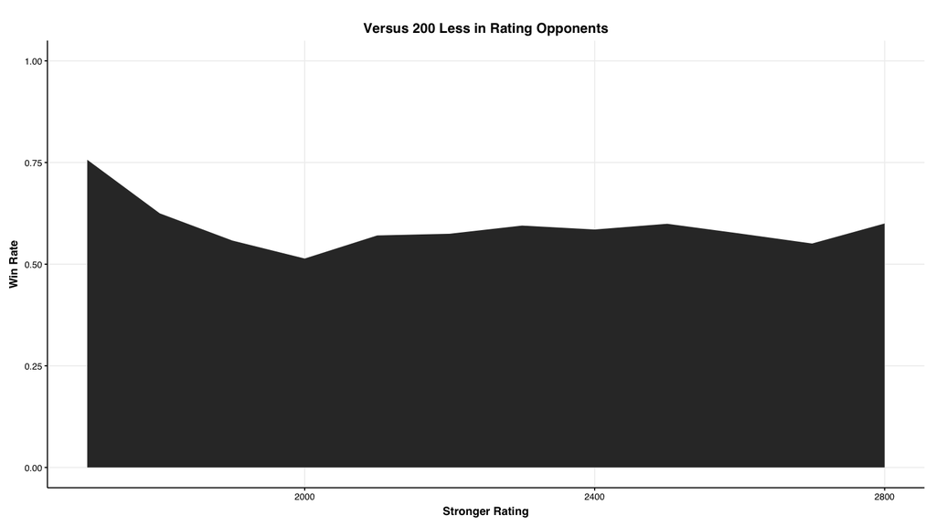

```r
distribution_for_test %>%
  mutate(Bigger_win_rate = (Bigger_w)/(Bigger_w+Bigger_l+Bigger_d)) %>%
  select(Bigger, Bigger_win_rate) %>%
  arrange(desc(Bigger)) %>%
  ggplot(aes(x = Bigger, y = Bigger_win_rate))+
  geom_area()+
  ggtitle("Versus 200 Less in Rating Opponents")+
  xlab("Stronger Rating")+
  ylab("Win Rate")+
  ylim(c(0,1))
```

مخزن گیت‌هاب پروژه

https://github.com/Mahbodmajid/DA_project_chess